# Data Visualization in R, Live Coding Companion

Follow along, modify, and keep this as a reference

Author

Siddhartha Bora

Published

May 28, 2026

## How to use this document

This companion mirrors the slide deck but with **more prose**, **all code runnable**, and **comments explaining every line**. Open this in RStudio alongside the slides. Each code chunk is independent enough that you can run them out of order if you want to skip around.

### Required packages

```r
install.packages(c(
  "tidyverse",   # ggplot2, dplyr, tidyr, readr, etc.
  "scales",      # axis label formatters
  "patchwork",   # combining plots
  "viridis",     # color palettes
  "colorspace",  # colorblindness simulation
  "sf",          # spatial data
  "tigris",      # US Census shapefiles
  "ggspatial",   # scale bars and north arrows for maps
  "ggrepel",     # non-overlapping text labels
  "ragg",        # better graphics device
  "here",        # path management
  "gapminder"    # example data
))
```

## 1. Tidy data

The three rules of tidy data (Wickham 2014):

1. Each **variable** is a column.
2. Each **observation** is a row.
3. Each **value** is a cell.

Why we care: `ggplot2` is built around tidy data. If your data isn’t tidy, plotting becomes a fight.

```r
library(tibble)

# Untidy: subjects encoded as column names
untidy <- tibble(
  student_id = c(1, 2, 3),
  english    = c(70, 78, 82),
  math       = c(87, 65, 91),
  science    = c(100, 83, 88)
)
untidy
```

```
# A tibble: 3 × 4
  student_id english  math science
       <dbl>   <dbl> <dbl>   <dbl>
1          1      70    87     100
2          2      78    65      83
3          3      82    91      88
```

```r
# Tidy: one row per (student, subject) observation
tidy <- tibble(
  student_id = rep(1:3, each = 3),
  subject    = rep(c("english", "math", "science"), times = 3),
  score      = c(70, 87, 100,
                 78, 65, 83,
                 82, 91, 88)
)
tidy
```

```
# A tibble: 9 × 3
  student_id subject score
       <int> <chr>   <dbl>
1          1 english    70
2          1 math       87
3          1 science   100
4          2 english    78
5          2 math       65
6          2 science    83
7          3 english    82
8          3 math       91
9          3 science    88
```

The key question: can you say “color the plot by subject”? Only with the tidy version, because only the tidy version *has* a `subject` column.

## 2. Long vs wide

```r
library(tidyr)

scores_wide <- tibble(
  student = c(1, 2, 3),
  english = c(70, 78, 82),
  math    = c(87, 65, 91),
  science = c(100, 83, 88)
)

# WIDE -> LONG via pivot_longer
scores_long <- scores_wide |>
  pivot_longer(
    cols      = -student,        # everything EXCEPT student
    names_to  = "subject",       # new column name for the old col names
    values_to = "score"          # new column name for the values
  )

scores_long
```

```
# A tibble: 9 × 3
  student subject score
    <dbl> <chr>   <dbl>
1       1 english    70
2       1 math       87
3       1 science   100
4       2 english    78
5       2 math       65
6       2 science    83
7       3 english    82
8       3 math       91
9       3 science    88
```

```r
# LONG -> WIDE via pivot_wider (the inverse)
scores_long |>
  pivot_wider(names_from = subject, values_from = score)
```

```
# A tibble: 3 × 4
  student english  math science
    <dbl>   <dbl> <dbl>   <dbl>
1       1      70    87     100
2       2      78    65      83
3       3      82    91      88
```

**Rule of thumb:** long for analysis/plotting; wide only for final tables shown to humans.

## 3. Your first ggplot

Every ggplot needs three things: data, an aesthetic mapping, and a geom.

```r
# The dataset `economics` is built into ggplot2
glimpse(economics)
```

```
Rows: 574
Columns: 6
$ date     <date> 1967-07-01, 1967-08-01, 1967-09-01, 1967-10-01, 1967-11-01, …
$ pce      <dbl> 506.7, 509.8, 515.6, 512.2, 517.4, 525.1, 530.9, 533.6, 544.3…
$ pop      <dbl> 198712, 198911, 199113, 199311, 199498, 199657, 199808, 19992…
$ psavert  <dbl> 12.6, 12.6, 11.9, 12.9, 12.8, 11.8, 11.7, 12.3, 11.7, 12.3, 1…
$ uempmed  <dbl> 4.5, 4.7, 4.6, 4.9, 4.7, 4.8, 5.1, 4.5, 4.1, 4.6, 4.4, 4.4, 4…
$ unemploy <dbl> 2944, 2945, 2958, 3143, 3066, 3018, 2878, 3001, 2877, 2709, 2…
```

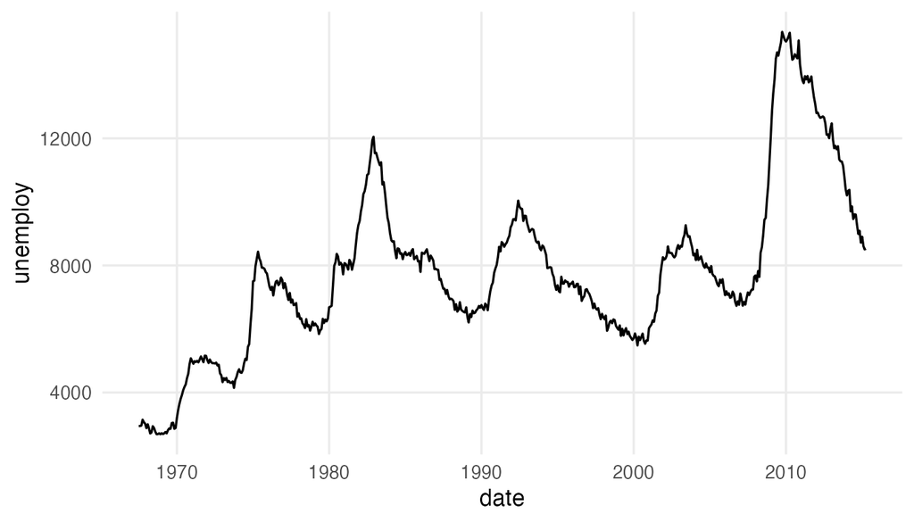

```r
# Minimal example
ggplot(data = economics, mapping = aes(x = date, y = unemploy)) +
  geom_line()
```

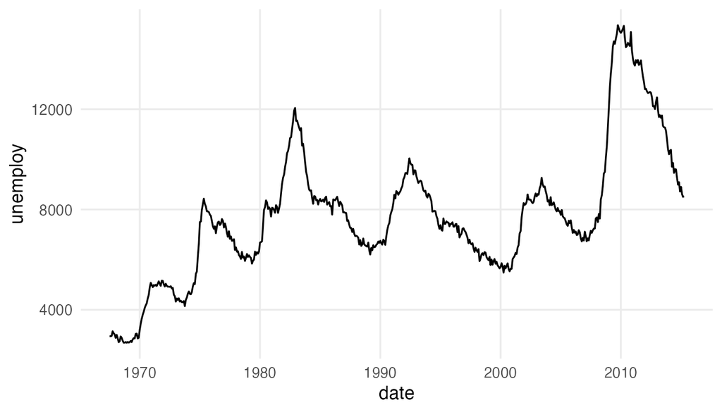

```r
# Idiomatic version: pipe data in, drop argument names
economics |>
  ggplot(aes(x = date, y = unemploy)) +
  geom_line()
```

Same data, different geom:

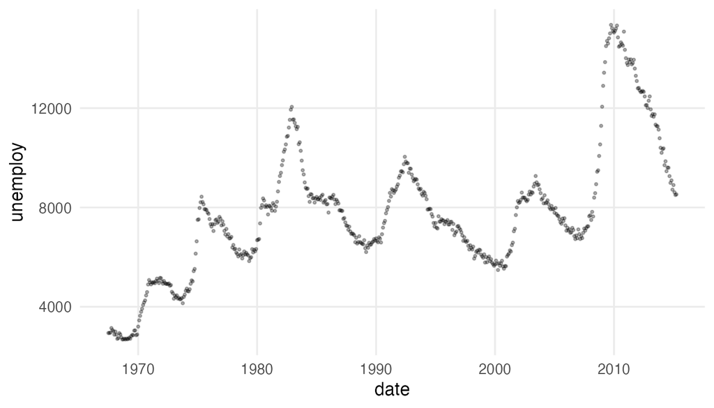

```r
economics |>
  ggplot(aes(x = date, y = unemploy)) +
  geom_point(alpha = 0.3, size = 0.6)
```

Mapping a variable to color:

```r
# economics_long stacks multiple economic indicators
glimpse(economics_long)
```

```
Rows: 2,870
Columns: 4
$ date     <date> 1967-07-01, 1967-08-01, 1967-09-01, 1967-10-01, 1967-11-01, …
$ variable <chr> "pce", "pce", "pce", "pce", "pce", "pce", "pce", "pce", "pce"…
$ value    <dbl> 506.7, 509.8, 515.6, 512.2, 517.4, 525.1, 530.9, 533.6, 544.3…
$ value01  <dbl> 0.0000000000, 0.0002652497, 0.0007615234, 0.0004706043, 0.000…
```

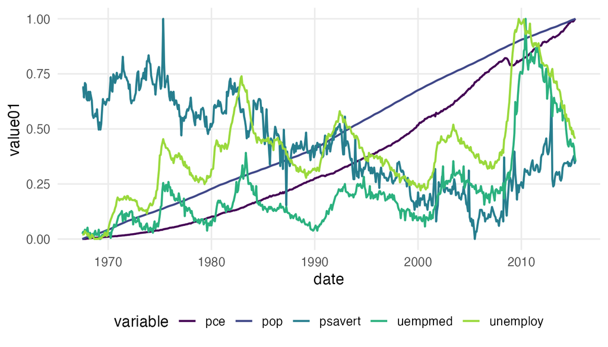

```r
economics_long |>
  ggplot(aes(x = date, y = value01, color = variable)) +
  geom_line(linewidth = 0.8) +
  scale_color_viridis_d(end = 0.85)
```

Notice: `color = variable` works because `variable` is a column. This is what tidy long data buys you.

## 4. Layer by layer: the worked example

Sample data: life expectancy at birth in three countries.

```r
life_exp <- tribble(
  ~country,  ~year, ~life_exp,
  "Brazil",   1990,  65.7,
  "Brazil",   2000,  70.1,
  "Brazil",   2010,  73.4,
  "Brazil",   2020,  75.9,
  "India",    1990,  58.5,
  "India",    2000,  62.6,
  "India",    2010,  66.6,
  "India",    2020,  70.2,
  "USA",      1990,  75.2,
  "USA",      2000,  76.8,
  "USA",      2010,  78.5,
  "USA",      2020,  77.0
)
```

### Step 1: the crudest version

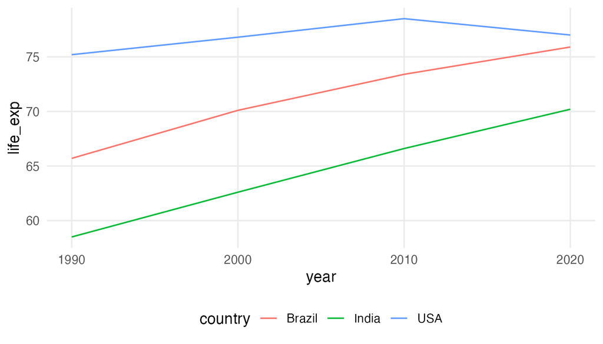

```r
p1 <- life_exp |>
  ggplot(aes(x = year, y = life_exp, color = country)) +
  geom_line()
p1
```

### Step 2: labels (treating the plot as an object)

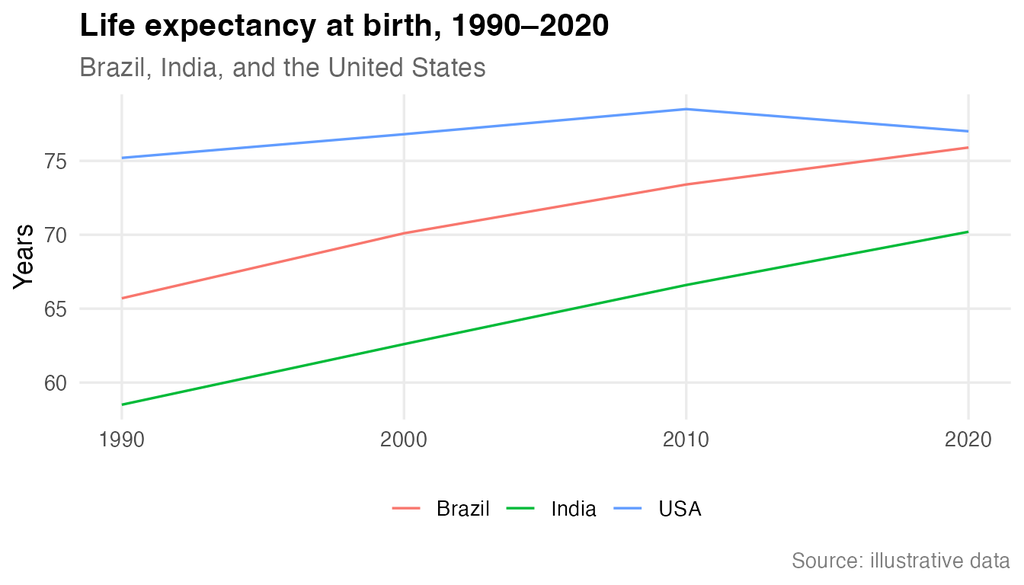

```r
p2 <- p1 +
  labs(
    title    = "Life expectancy at birth, 1990–2020",
    subtitle = "Brazil, India, and the United States",
    x        = NULL,
    y        = "Years",
    color    = NULL,
    caption  = "Source: illustrative data"
  )
p2
```

### Step 3: line weight and points

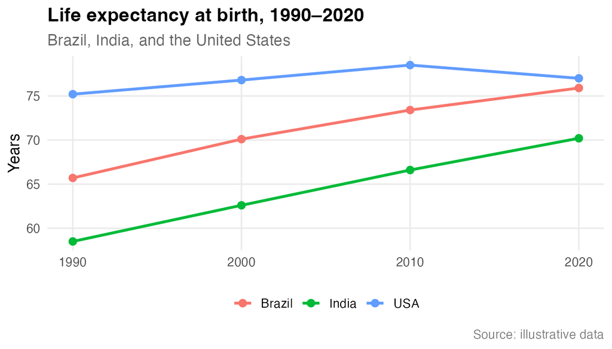

```r
# NOTE: linewidth, not size. ggplot 3.4.0 (2022) deprecated `size` for lines.
p3 <- p2 +
  geom_line(linewidth = 1.1) +
  geom_point(size = 2.5)
p3
```

### Step 4: deliberate color palette

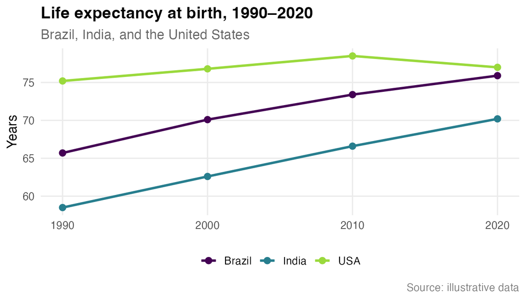

```r
# viridis is perceptually uniform AND colorblind-safe
p4 <- p3 +
  scale_color_viridis_d(option = "D", end = 0.85)
p4
```

### Step 5: a clean theme

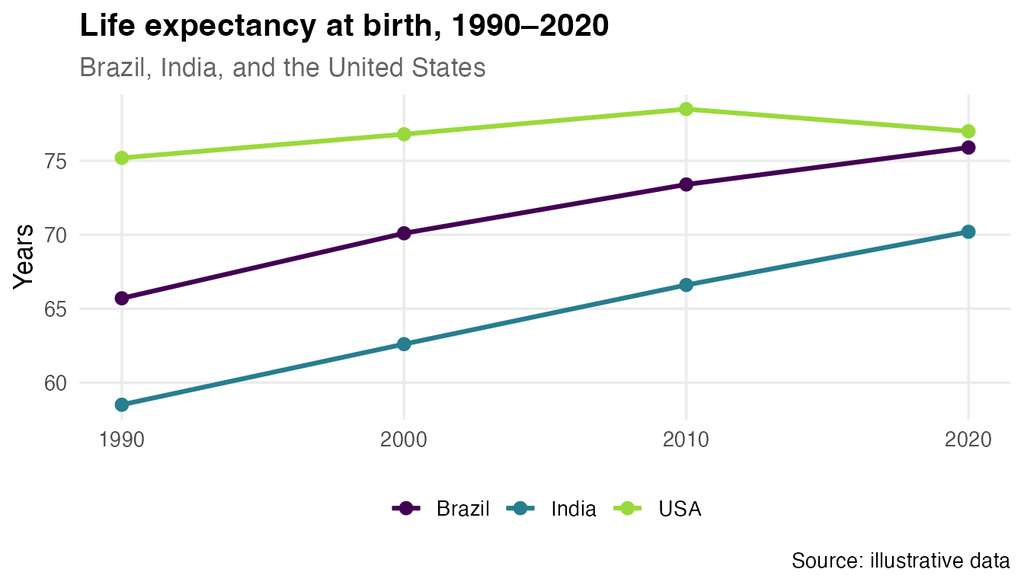

```r
p5 <- p4 +
  theme_minimal(base_size = 13) +
  theme(
    plot.title       = element_text(face = "bold"),
    plot.subtitle    = element_text(color = "grey40"),
    legend.position  = "bottom",
    panel.grid.minor = element_blank()
  )
p5
```

### Step 6: axis breaks and limits

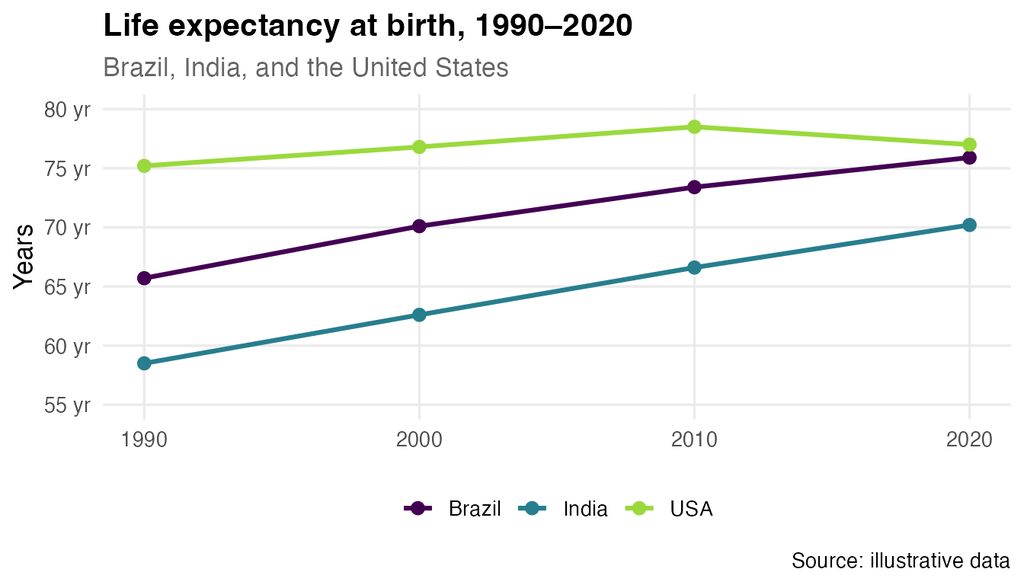

```r
p6 <- p5 +
  scale_x_continuous(breaks = seq(1990, 2020, 10)) +
  scale_y_continuous(
    limits = c(55, 80),
    labels = scales::label_number(suffix = " yr")
  )
p6
```

The before/after:

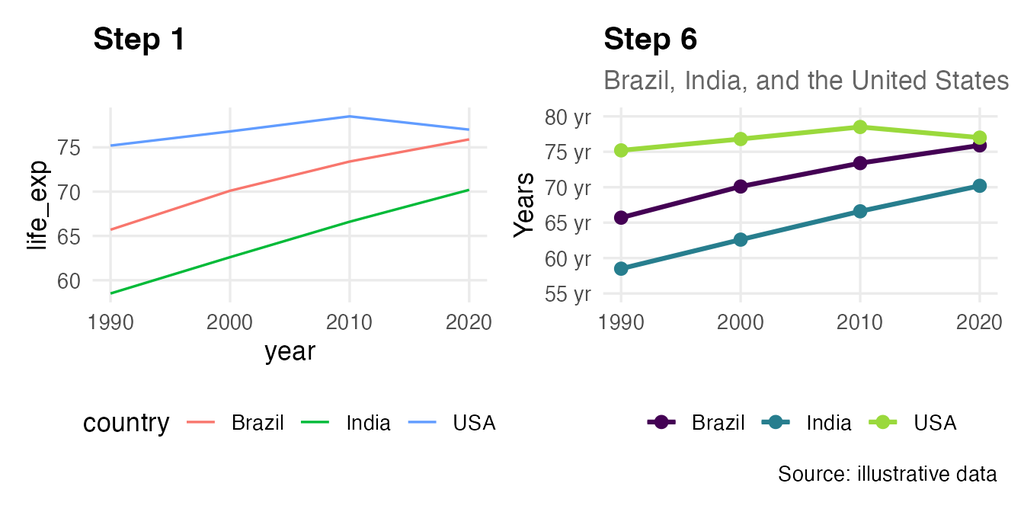

```r
library(patchwork)
(p1 + ggtitle("Step 1")) + (p6 + ggtitle("Step 6"))
```

**Key insight:** you didn’t write a 50-line plotting function. You added six small, named layers. If you change your mind about color later, you change one line.

## 5. Color, deliberately

Three kinds of color scale, picked first by the *type* of variable:

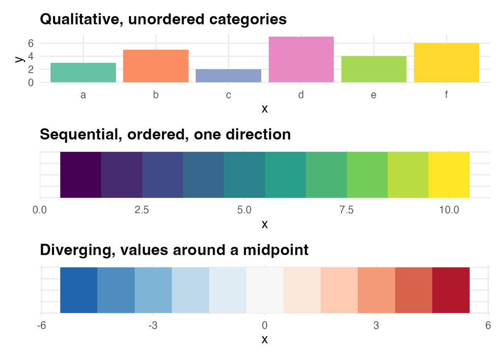

```r
library(patchwork)

df_qual <- tibble(x = letters[1:6], y = c(3, 5, 2, 7, 4, 6))
df_seq  <- tibble(x = 1:10)
df_div  <- tibble(x = -5:5)

p_qual <- ggplot(df_qual, aes(x, y, fill = x)) +
  geom_col() +
  scale_fill_brewer(palette = "Set2") +
  labs(title = "Qualitative, unordered categories") +
  theme(legend.position = "none")

p_seq <- ggplot(df_seq, aes(x, y = 1, fill = x)) +
  geom_tile() +
  scale_fill_viridis_c() +
  labs(title = "Sequential, ordered, one direction") +
  theme(legend.position = "none",
        axis.text.y = element_blank(),
        axis.title.y = element_blank())

p_div <- ggplot(df_div, aes(x, y = 1, fill = x)) +
  geom_tile() +
  scale_fill_distiller(palette = "RdBu", limits = c(-5, 5)) +
  labs(title = "Diverging, values around a midpoint") +
  theme(legend.position = "none",
        axis.text.y = element_blank(),
        axis.title.y = element_blank())

p_qual / p_seq / p_div
```

The functions to remember:

```r
# Discrete (categorical)
scale_color_viridis_d()
scale_color_brewer(palette = "Set2")
scale_color_manual(values = c("group1" = "#E69F00", "group2" = "#56B4E9"))

# Continuous
scale_color_viridis_c()
scale_color_gradient(low = "white", high = "darkgreen")
scale_color_gradient2(low = "blue", mid = "white", high = "red", midpoint = 0)

# Replace _color_ with _fill_ for fill aesthetics
```

Default ggplot colors look colorful but aren’t perceptually uniform or colorblind-safe. **Pick a palette deliberately, once per project.**

The Okabe-Ito palette, designed specifically for colorblind accessibility:

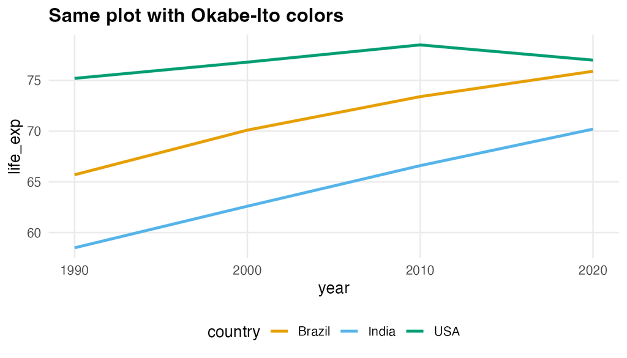

```r
# The canonical 8-color Okabe-Ito palette (matches R/helpers.R). The first
# color is black, so skip it with `[-1]` when you don't want a black series.
okabe_ito <- c("#000000", "#E69F00", "#56B4E9", "#009E73",
               "#F0E442", "#0072B2", "#D55E00", "#CC79A7")

# Used as a manual scale
ggplot(life_exp, aes(year, life_exp, color = country)) +
  geom_line(linewidth = 1.1) +
  scale_color_manual(values = okabe_ito[-1]) +
  labs(title = "Same plot with Okabe-Ito colors")
```

## 6. Themes

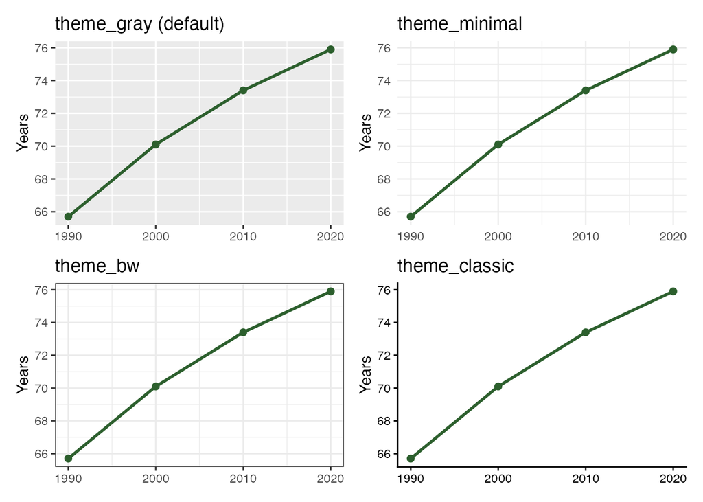

```r
p_base_demo <- ggplot(life_exp |> filter(country == "Brazil"),
                      aes(year, life_exp)) +
  geom_line(linewidth = 1, color = "#2c5f2d") +
  geom_point(size = 2, color = "#2c5f2d") +
  labs(x = NULL, y = "Years")

(p_base_demo + theme_gray()    + ggtitle("theme_gray (default)")) +
(p_base_demo + theme_minimal() + ggtitle("theme_minimal")) +
(p_base_demo + theme_bw()      + ggtitle("theme_bw")) +
(p_base_demo + theme_classic() + ggtitle("theme_classic"))
```

Set a project-wide theme at the top of every script:

```r
theme_set(
  theme_minimal(base_size = 13) +
    theme(
      plot.title       = element_text(face = "bold"),
      plot.subtitle    = element_text(color = "grey40"),
      panel.grid.minor = element_blank(),
      legend.position  = "bottom"
    )
)
```

Every plot in the script now inherits this theme. Change your mind? Change one block.

## 7. Number formatting

The `scales` package is essential for axis labels.

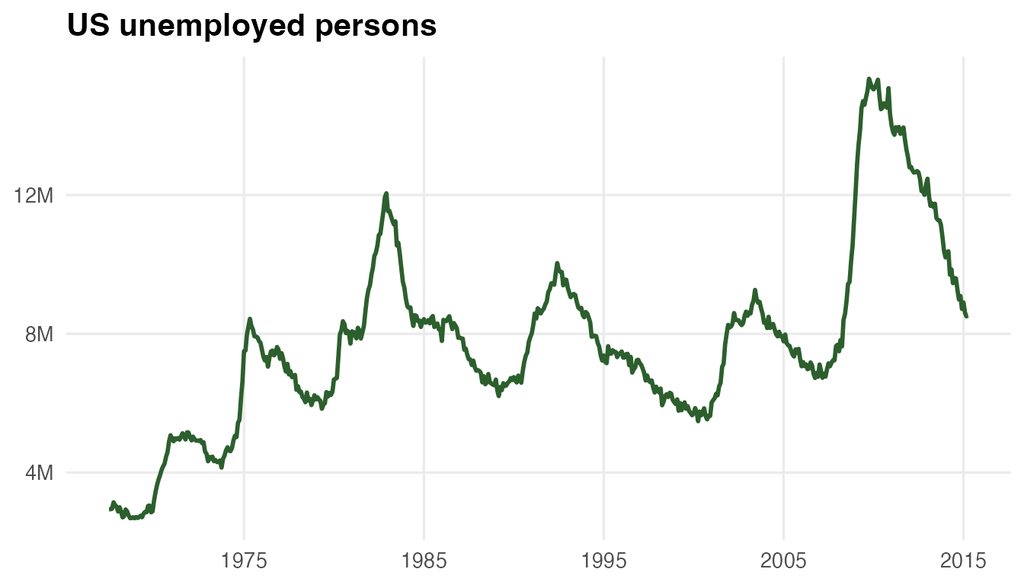

```r
library(scales)

ggplot(economics, aes(date, unemploy * 1000)) +
  geom_line(linewidth = 1, color = "#2c5f2d") +
  scale_y_continuous(labels = label_number(scale = 1e-6, suffix = "M")) +
  scale_x_date(date_breaks = "10 years", date_labels = "%Y") +
  labs(title = "US unemployed persons", x = NULL, y = NULL)
```

The label helpers:

```r
label_number(scale = 1e-6, suffix = "M")    # 5000000 -> "5M"
label_percent(accuracy = 0.1)                # 0.123 -> "12.3%"
label_comma()                                # 1000000 -> "1,000,000"
label_dollar()                               # 1234 -> "$1,234"
label_date()                                 # date formatting
label_log()                                  # log scale labels
```

## 8. Accessibility

```r
library(colorspace)

# Simulate three common color vision deficiencies
deutan(c("red", "green", "blue"))   # deuteranopia (red-green, most common)
```

```
[1] "#A39000" "#EFD63A" "#003DFB"
```

```r
protan(c("red", "green", "blue"))   # protanopia (red-green)
```

```
[1] "#6D5F00" "#FFE500" "#0059FF"
```

```r
tritan(c("red", "green", "blue"))   # tritanopia (blue-yellow, rare)
```

```
[1] "#FF000F" "#00F7D9" "#006B96"
```

What does my plot look like to someone with deuteranopia?

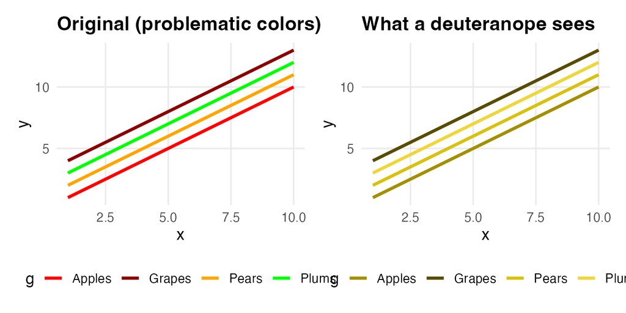

```r
# A bad-on-purpose plot using close reds and greens
bad_df <- tibble(
  x = rep(1:10, 4),
  y = c(1:10, 2:11, 3:12, 4:13),
  g = rep(c("Apples", "Pears", "Plums", "Grapes"), each = 10)
)

bad_p <- ggplot(bad_df, aes(x, y, color = g)) +
  geom_line(linewidth = 1.2) +
  scale_color_manual(values = c("red", "darkred", "orange", "green")) +
  labs(title = "Original (problematic colors)")

# Same plot through deuteranope simulation
bad_p_deutan <- ggplot(bad_df, aes(x, y, color = g)) +
  geom_line(linewidth = 1.2) +
  scale_color_manual(values = deutan(c("red", "darkred", "orange", "green"))) +
  labs(title = "What a deuteranope sees")

bad_p + bad_p_deutan
```

The fix, redundant encoding. Don’t rely on color alone:

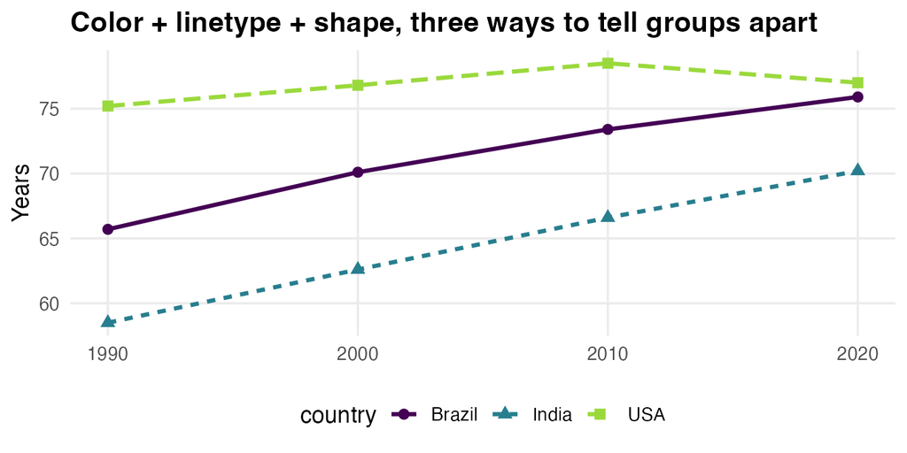

```r
# Color + linetype + shape: survives grayscale, colorblindness, low contrast
ggplot(life_exp, aes(year, life_exp,
                     color = country, linetype = country, shape = country)) +
  geom_line(linewidth = 1.1) +
  geom_point(size = 2.5) +
  scale_color_viridis_d(end = 0.85) +
  labs(title = "Color + linetype + shape, three ways to tell groups apart",
       x = NULL, y = "Years")
```

**The test:** print your figure in grayscale. Can you still read it?

For Quarto/HTML output, add alt text:

````markdown
```{r}
#| label: fig-life-exp
#| fig-cap: "Life expectancy in three countries, 1990–2020"
#| fig-alt: "Line chart showing life expectancy rising in Brazil
#|   and India and plateauing in the US between 1990 and 2020."
ggplot(life_exp, ...) + ...
```
````

Alt text should describe the **takeaway**, not the chart type. A screen-reader user needs “life expectancy plateaued in the US”, not “a line chart with three colored lines.”

## 9. Faceting: small multiples

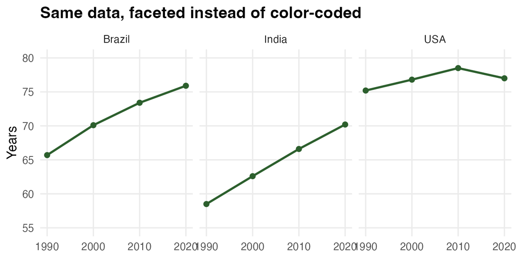

```r
life_exp |>
  ggplot(aes(year, life_exp)) +
  geom_line(linewidth = 1, color = "#2c5f2d") +
  geom_point(size = 2, color = "#2c5f2d") +
  facet_wrap(~ country) +
  scale_y_continuous(limits = c(55, 80)) +
  labs(title = "Same data, faceted instead of color-coded",
       x = NULL, y = "Years")
```

```r
# facet_grid for crossing two variables
ggplot(df, aes(x, y)) + geom_point() + facet_grid(year ~ region)

# Free y-scales when ranges differ a lot
ggplot(df, aes(x, y)) + geom_line() + facet_wrap(~ region, scales = "free_y")

# Better facet labels
ggplot(df, aes(x, y)) + geom_line() + facet_wrap(~ region, labeller = label_both)
```

## 10. Maps with `sf`

A map is a data frame with a `geometry` column. Once you accept that, the rest is just ggplot.

```r
library(sf)
library(tigris)
library(dplyr)

# Always cache shapefiles: they're large
options(tigris_use_cache = TRUE)

# Get state geometry (cb = TRUE for cartographic boundaries: smaller files)
us_states <- states(cb = TRUE, year = 2024, resolution = "20m")

# Inspect: it's just a data frame with a special geometry column
glimpse(us_states)
```

A minimal choropleth:

```r
# Make some data to join
my_data <- tibble(
  state_abbr = state.abb,
  value      = runif(50, 0, 100)
)

states_with_data <- us_states |>
  left_join(my_data, by = c("STUSPS" = "state_abbr"))

ggplot(states_with_data) +
  geom_sf(aes(fill = value), color = "white", linewidth = 0.2) +
  scale_fill_viridis_c() +
  labs(title = "US states, example choropleth") +
  theme_void()
```

### Projections

Default unprojected lon/lat coordinates produce a “stretched” US map.

```r
# Default: looks stretched
ggplot(us_states) + geom_sf()

# Albers Equal Area: the right projection for continental US
ggplot(us_states) +
  geom_sf() +
  coord_sf(crs = "EPSG:5070")

# Shift Alaska and Hawaii to fit on a national map
library(tigris)
us_states |>
  shift_geometry() |>
  ggplot() +
  geom_sf() +
  coord_sf(crs = "EPSG:5070")
```

Picking a projection for somewhere other than the US:

```r
library(crsuggest)
suggest_crs(my_sf_object)   # suggests appropriate projected CRSs
```

### Faceted comparison map

```r
# Compare two states' counties side by side
two_states <- counties(state = c("WV", "OH"), cb = TRUE, year = 2024) |>
  left_join(my_county_data, by = "GEOID")

ggplot(two_states) +
  geom_sf(aes(fill = food_insecurity_rate), color = "white", linewidth = 0.1) +
  scale_fill_viridis_c(option = "D", labels = scales::label_percent()) +
  facet_wrap(~ STATE_NAME) +                  # coord_sf() forbids scales = "free"
  labs(title = "Food insecurity by county",
       subtitle = "Ohio vs West Virginia, 2021",
       fill     = NULL) +
  theme_void(base_size = 12) +
  theme(strip.text = element_text(face = "bold", size = 13))
```

### Map polish

```r
library(ggspatial)   # scale bars and north arrows for ggplot
library(ggrepel)     # non-overlapping labels

ggplot(my_map) +
  geom_sf(aes(fill = value), color = "white", linewidth = 0.1) +

  # Right scale type for the data
  scale_fill_distiller(palette = "RdBu", direction = -1, labels = label_percent()) +

  # Direct labels for the regions
  geom_sf_text(aes(label = NAME), size = 3, color = "grey20") +

  # Drop axes: they're noise on a choropleth
  theme_void(base_size = 12) +

  # Optional: scale bar / north arrow when precision matters
  annotation_scale(location = "br") +
  annotation_north_arrow(location = "tr", style = north_arrow_minimal()) +

  # Always caption your data source
  labs(title    = "My map title",
       caption  = "Source: USDA AMS, 2024",
       fill     = NULL)
```

## 11. Combining plots: `patchwork`

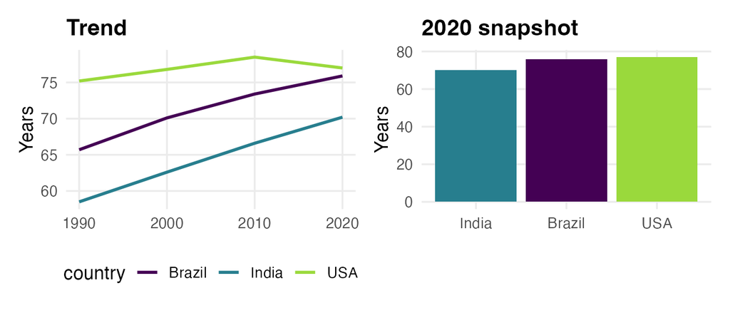

```r
p_left <- ggplot(life_exp, aes(year, life_exp, color = country)) +
  geom_line(linewidth = 1) +
  scale_color_viridis_d(end = 0.85) +
  labs(title = "Trend", x = NULL, y = "Years")

p_right <- ggplot(life_exp |> filter(year == 2020),
                  aes(reorder(country, life_exp), life_exp, fill = country)) +
  geom_col() +
  scale_fill_viridis_d(end = 0.85, guide = "none") +
  labs(title = "2020 snapshot", x = NULL, y = "Years")

p_left + p_right
```

The operators:

```r
p1 + p2                           # side by side
p1 / p2                           # stacked
(p1 + p2) / p3                    # nested layout
p1 | p2 | p3                      # also side by side, explicit

# Shared title + auto-labels
(p1 + p2) +
  plot_annotation(title = "Shared title",
                  tag_levels = "A")

# Collect duplicated legends
(p1 + p2) + plot_layout(guides = "collect")
```

You’ll see `gridExtra::grid.arrange()` in older code. `patchwork` is the modern default, cleaner syntax and better alignment.

## 12. Exporting

```r
# PNG: use the ragg device (faster, better fonts, cross-platform consistent)
ggsave(
  filename = "fig-1.png",
  plot     = p,
  width    = 7, height = 4,   # build at FINAL display size
  units    = "in",
  dpi      = 300,             # 300 for print, 150 for screen
  device   = ragg::agg_png    # the modern recommendation
)

# PDF: use cairo_pdf to embed fonts properly
ggsave("fig-1.pdf", p,
       width = 7, height = 4, units = "in",
       device = cairo_pdf)

# SVG: for scalable vector (web, Adobe Illustrator)
ggsave("fig-1.svg", p, width = 7, height = 4, units = "in")
```

**Pitfalls to avoid:**

- Resizing in Word/PowerPoint after export → text gets warped. Set size in `ggsave`.
- Fonts substituting in PDF → use `device = cairo_pdf`.
- “Different output on different OS” → `ragg` minimizes this.

## 13. Reproducibility

A minimal reproducible setup:

```r
# Top of every analysis script
library(here)
library(tidyverse)
library(sf)

set.seed(42)

# Paths via here(): work no matter where the script is run from.
# Replace "my-data.csv" with your actual file in data/raw/.
data <- read_csv(here("data", "raw", "my-data.csv"))

# ... your analysis ...

# At the bottom
sessionInfo()
```

In the terminal, once per project:

```r
renv::init()       # set up renv
renv::snapshot()   # lock current package versions to renv.lock
```

**If you can’t hand your project to a stranger and have it run in 10 minutes, it’s not done.**

## 14. Beyond static

```r
# Quickest path to interactive: wraps any ggplot
library(plotly)
ggplotly(p)
```

```r
# Interactive web maps
library(leaflet)
leaflet(my_sf_data) |>
  addTiles() |>
  addPolygons(fillColor = ~viridis::viridis(10)[as.numeric(cut(value, 10))],
              fillOpacity = 0.7)
```

```r
# tmap is an alternative to ggplot for maps (v4 in 2025)
# Switches between static "plot" and interactive "view" modes
library(tmap)
tmap_mode("plot")
tm_shape(my_sf) + tm_polygons(fill = "value")
```

**Caveat:** interactive ≠ better. For a printed report or PDF, static is correct.

## 15. Common pitfalls

**Misleading visualizations to avoid:**

- Truncated y-axis on bar charts
- Dual y-axes
- Pie charts beyond 3 slices
- 3D anything
- Rainbow / jet colormaps (perceptually non-uniform; fail under colorblindness)
- Encoding ordering in hue alone

**Portability:**

- Hardcoded paths (`/Users/me/...`): use `here::here()`
- `setwd()` anywhere in code: use RStudio projects
- Random seeds not set: `set.seed(42)` whenever randomness is involved
- No `sessionInfo()`: add at bottom of every analysis file

## 16. Capstone: assemble a shareable figure

Nothing new here. Every piece came from an earlier section: tidy data, a deliberate palette, the house theme, small multiples via `patchwork`, a controlled export. Communication is *assembly*, choose the views that answer the reader’s question, then make the result stand on its own. The full worked example, a US-states variant with a tigris map, is in `demos/21-infographic.R`.

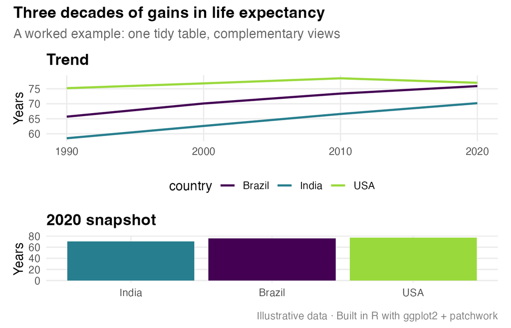

```r
# Reuse the two plots built in section 11
figure <- (p_left) / (p_right) +
  plot_layout(heights = c(1.4, 1)) +
  plot_annotation(
    title    = "Three decades of gains in life expectancy",
    subtitle = "A worked example: one tidy table, complementary views",
    caption  = "Illustrative data · Built in R with ggplot2 + patchwork"
  )
figure
```

Then export it once, at a fixed size and DPI, so it looks identical in a slide, a PDF, and the web:

```r
ggsave(
  here("figures", "capstone-infographic.png"),
  plot = figure, device = ragg::agg_png,
  width = 9, height = 7.5, units = "in", dpi = 300, bg = "white"
)
```

## Resources

**Books**

- [R for Data Science (2e)](https://r4ds.hadley.nz/)
- [ggplot2: Elegant Graphics for Data Analysis (3e)](https://ggplot2-book.org/)
- [Geocomputation with R](https://r.geocompx.org/)
- [Analyzing US Census Data](https://walker-data.com/census-r/)
- [Advanced R (2e)](https://adv-r.hadley.nz/)
- [Happy Git and GitHub for the useR](https://happygitwithr.com/)

**Galleries**

- [R Graph Gallery](https://r-graph-gallery.com/)
- [ggplot2 extensions](https://exts.ggplot2.tidyverse.org/gallery/)

**Accessibility**

- [Color Universal Design (Okabe & Ito)](https://jfly.uni-koeln.de/color/)
- [WCAG 2.1 quick reference](https://www.w3.org/WAI/WCAG21/quickref/)

**Quarto**

- [Quarto Guide](https://quarto.org/docs/guide/)